# Project 1: Physical Attributes of NFL players

Group 4, Section 11

2023-10-23

# Introduction

## About the Project

**In an NFL game, each team has 11 players on the field at any given point in time. While the offensive team tries to advance the ball and score a touch down, the defensive team tries to stop them and win possession of the ball. Each team has different players for offense and defense known as “rotations” and both rotations have different positions with specific roles.**  
**Our objective in this project is to study the physical characteristics of players in relation to their position of play. In particular, we focus on the height and weight distributions of the players. Additionally, we are interested in studying the years of experience (YOE) of players to determine their “longevity” in the league. In a sport as physical as NFL, frequent injuries take a toll on the body and end up reducing a player’s tenure. We are interested to use the YOE to determine which positions tend to have players staying longer in the league.**

## About the dataset

**For this project, we have selected this [NFLverse dataset](https://github.com/nflverse/nflverse-data/releases/download/players/players.csv) from GitHub. The dataset contains information about players who have entered and played in the NFL from 1980s to 2023.**

```r
nfl_data = read.csv("../dataset/nfl_players.csv")
```

## Cleaning the dataset

For our project, we are only interested in some of the variables and we will only focus on players who have entered the league from 2000-2023.

```r
nfl_data = nfl_data[, c("position_group", "position", "height", "weight", "years_of_experience", "team_abbr", "entry_year", "rookie_year")]
nfl_data_clean = na.omit(nfl_data)
nfl_data_clean = subset(nfl_data_clean, nfl_data_clean$entry_year >= 2000)
```

**After cleaning, we are left with 7098 observations of 8 variables.**

```r
write.csv(nfl_data_clean, "../dataset/nfl_players_clean.csv", row.names = F)
```

## Factorize and summarize the cleaned data

```r
nfl_data_clean$position_group = as.factor(nfl_data_clean$position_group)
nfl_data_clean$position = as.factor(nfl_data_clean$position)
nfl_data_clean$team_abbr = as.factor(nfl_data_clean$team_abbr)
nfl_data_clean$entry_year = as.factor(nfl_data_clean$entry_year)
nfl_data_clean$rookie_year = as.factor(nfl_data_clean$rookie_year)
```

**There are a total of 7098 players in the dataset, playing in 28 different positions grouped into 9 different position groups.**

```r
summary(nfl_data_clean, maxsum = 40)
```

```
##  position_group position      height         weight    years_of_experience
##  DB  :1349      C  :218   Min.   :66.0   Min.   :153   Min.   : 0.00
##  DL  :1002      CB :660   1st Qu.:72.0   1st Qu.:203   1st Qu.: 0.00
##  LB  : 989      DB :259   Median :74.0   Median :232   Median : 2.00
##  OL  :1168      DE :475   Mean   :74.1   Mean   :242   Mean   : 3.43
##  QB  : 258      DL :  1   3rd Qu.:76.0   3rd Qu.:282   3rd Qu.: 5.00
##  RB  : 584      DT :447   Max.   :82.0   Max.   :380   Max.   :21.00
##  SPEC: 280      FB : 65
##  TE  : 477      FS :216
##  WR  : 991      G  :363
##                 HB :  3
##                 ILB:282
##                 K  :100
##                 LB :252
##                 LS : 84
##                 MLB: 66
##                 NT : 81
##                 OG : 73
##                 OLB:388
##                 OT : 79
##                 P  : 96
##                 QB :258
##                 RB :518
##                 S  :  6
##                 SAF:  7
##                 SS :199
##                 T  :435
##                 TE :476
##                 WR :991
##
##
##
##
##
##
##
##  team_abbr entry_year rookie_year
##  ARI:271   2000:  3   2000:  3
##  ATL:229   2001:  1   2001:  1
##  BAL:203   2002:  7   2002:  7
```

[output cut: 17 more lines]

```
##  MIN:191   2020:622   2020:612
##  NE :176   2021:345   2021:345
##  NO :243   2022:509   2022:511
##  NYG:277   2023:674   2023:684
##  NYJ:221
##  OAK: 71
##  PHI:208
##  PIT:248
##  SD :  7
##  SEA:239
##  SF :215
##  STL:  2
##  TB :247
##  TEN:256
##  WAS:254
```

# Diving into each variable

After cleaning up the dataset and looking at the summary, we shift our focus to analyzing the distribution for each variable.

## Position group

**There are 9 different position groups in this dataset. The number of players in each position group are as follows:**

```r
summary(nfl_data_clean$position_group)
```

```
##   DB   DL   LB   OL   QB   RB SPEC   TE   WR
## 1349 1002  989 1168  258  584  280  477  991
```

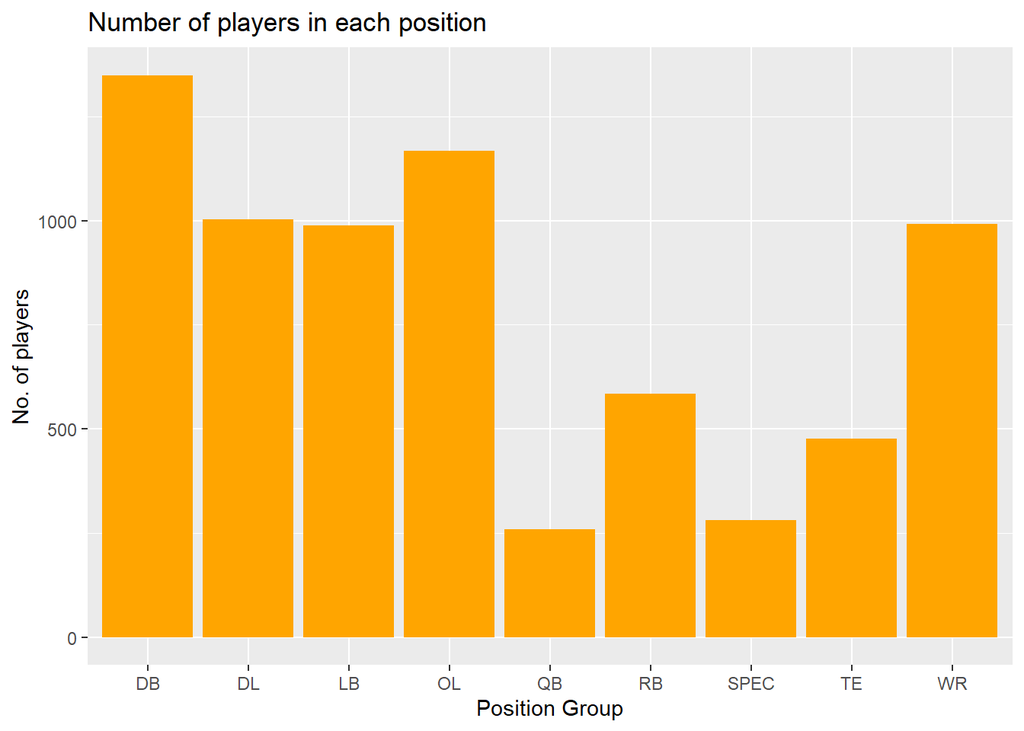

```r
ggplot(nfl_data_clean, aes(x = position_group)) +
  geom_bar(fill = "orange") +
  labs(title = "Number of players in each position", x="Position Group", y="No. of players")
```

## Height

The height of each player measured in inches is recorded in the `height` variable. To study the distribution of height, we look at the summary statistics, histogram, boxplot and q-q plot.

```r
summary(nfl_data_clean$height)
```

```
##    Min. 1st Qu.  Median    Mean 3rd Qu.    Max.
##    66.0    72.0    74.0    74.1    76.0    82.0
```

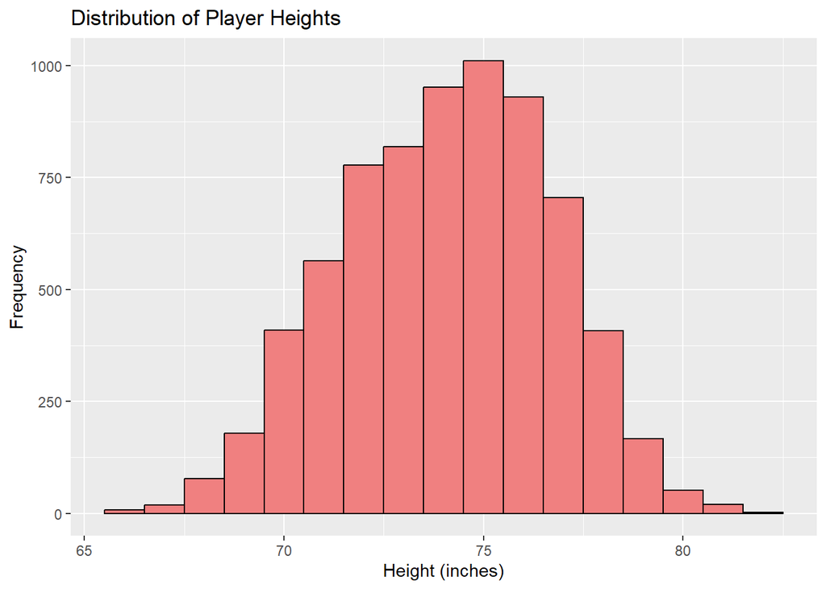

```r
ggplot(nfl_data_clean, aes(x = height)) +
  geom_histogram(binwidth = 1, fill = "lightcoral", color = "black") +
  labs(title = "Distribution of Player Heights", x = "Height (inches)", y = "Frequency")
```

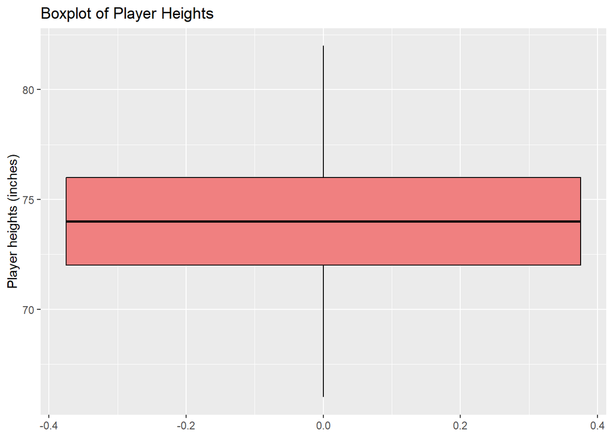

```r
ggplot(nfl_data_clean) +
  geom_boxplot(aes(y=height), fill="lightcoral", color="black") +
  labs(title = "Boxplot of Player Heights", y = "Player heights (inches)")
```

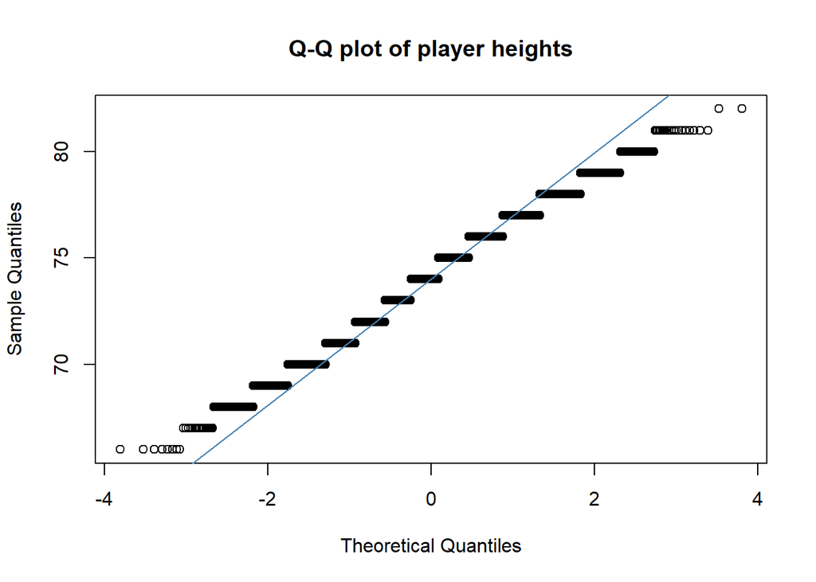

```r
qqnorm(nfl_data_clean$height, main = "Q-Q plot of player heights")
qqline(nfl_data_clean$height, col="steelblue")
```

## Weight

The weight of each player measured in pounds is recorded in the `weight` variable. To study the distribution of weight, we look at the summary statistics, histogram, boxplot and q-q plot.

```r
summary(nfl_data_clean$weight)
```

```
##    Min. 1st Qu.  Median    Mean 3rd Qu.    Max.
##     153     203     232     242     282     380
```

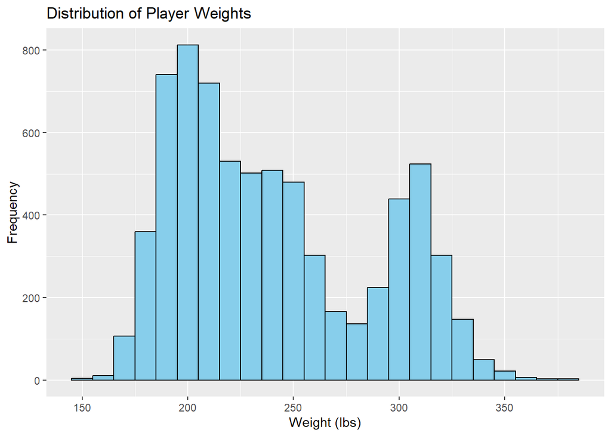

```r
ggplot(nfl_data_clean, aes(x = weight)) +
  geom_histogram(binwidth = 10, fill = "skyblue", color = "black") +
  labs(title = "Distribution of Player Weights", x = "Weight (lbs)", y = "Frequency")
```

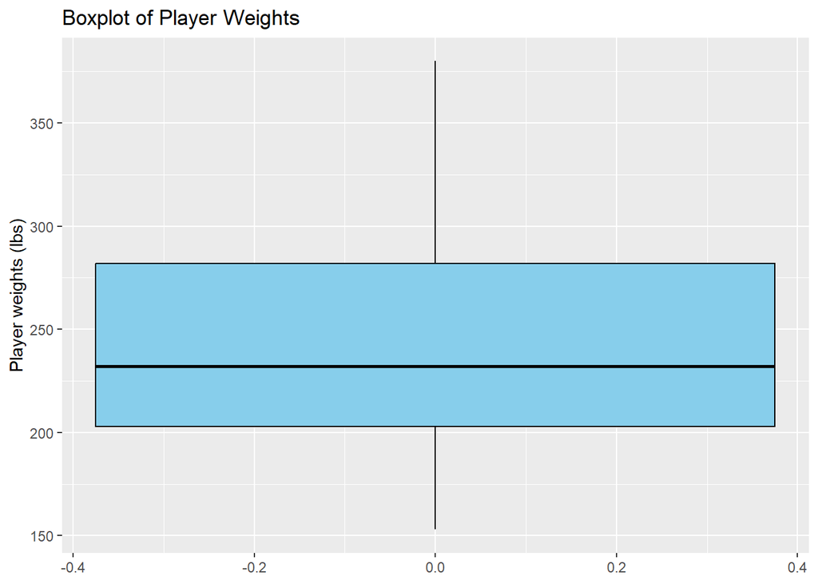

```r
ggplot(nfl_data_clean) +
  geom_boxplot(aes(y=weight), fill="skyblue", color="black") +
  labs(title = "Boxplot of Player Weights", y = "Player weights (lbs)")
```

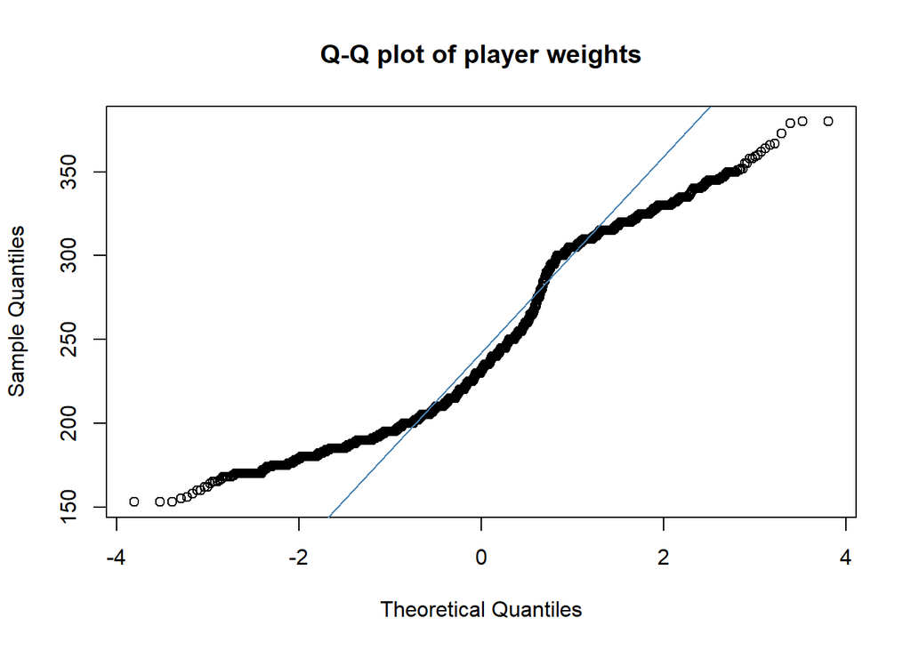

```r
qqnorm(nfl_data_clean$weight, main = "Q-Q plot of player weights")
qqline(nfl_data_clean$weight, col="steelblue")
```

## Years of experience

```r
summary(nfl_data_clean$years_of_experience)
```

```
##    Min. 1st Qu.  Median    Mean 3rd Qu.    Max.
##    0.00    0.00    2.00    3.43    5.00   21.00
```

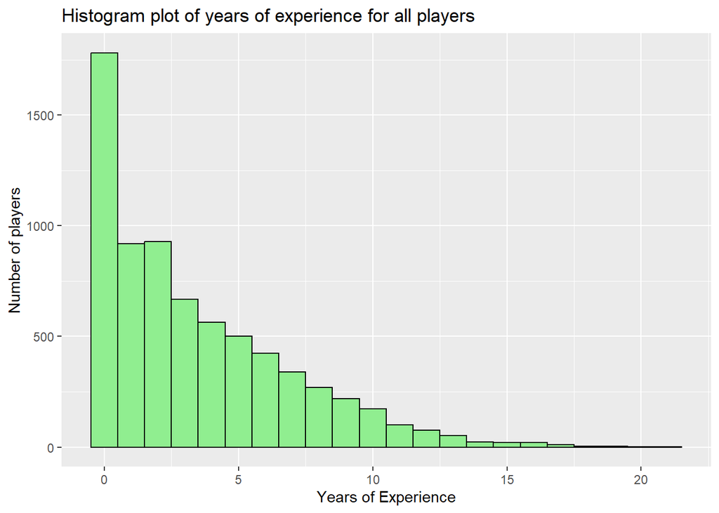

```r
ggplot(nfl_data_clean) +
  geom_histogram(aes(x=years_of_experience), color="black", fill="lightgreen", binwidth = 1, show.legend = F) +
  labs(title = "Histogram plot of years of experience for all players") +
  labs(x = "Years of Experience", y="Number of players")
```

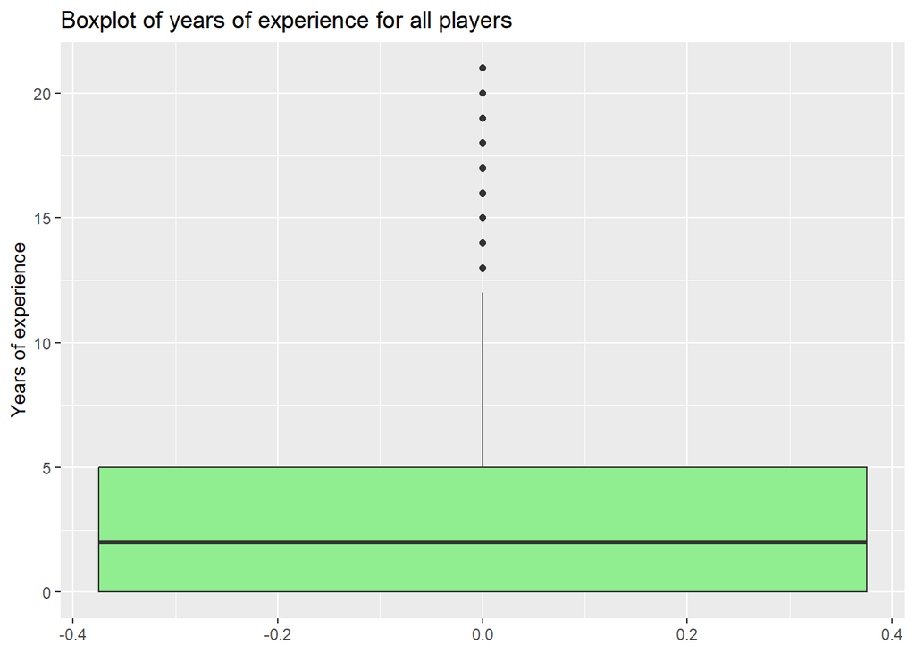

```r
ggplot(nfl_data_clean) +
  geom_boxplot(aes(y=years_of_experience), fill="lightgreen", show.legend = F) +
  labs(title = "Boxplot of years of experience for all players") +
  labs(y = "Years of experience")
```

[figure not shown]

```r
qqnorm(nfl_data_clean$height, main = "Q-Q plot of Years of experience")
qqline(nfl_data_clean$height, col="steelblue")
```

# Studying each variable by position group

Now we study the distribution of weight, height and YOE with respect to the position group. Additionally, we also use ANOVA tests to determine the presence of a correlation between the variables of interest and position groups.  
First, we group the dataset by position group and calculate the average weight, height, and YOE for each position group.

```r
grouped_nfl_players <- group_by(nfl_data_clean, position_group)

nfl_players_by_position <- summarize(grouped_nfl_players,average_height = mean(height),average_weight = mean(weight), average_years_active = mean(years_of_experience))
```

## Height

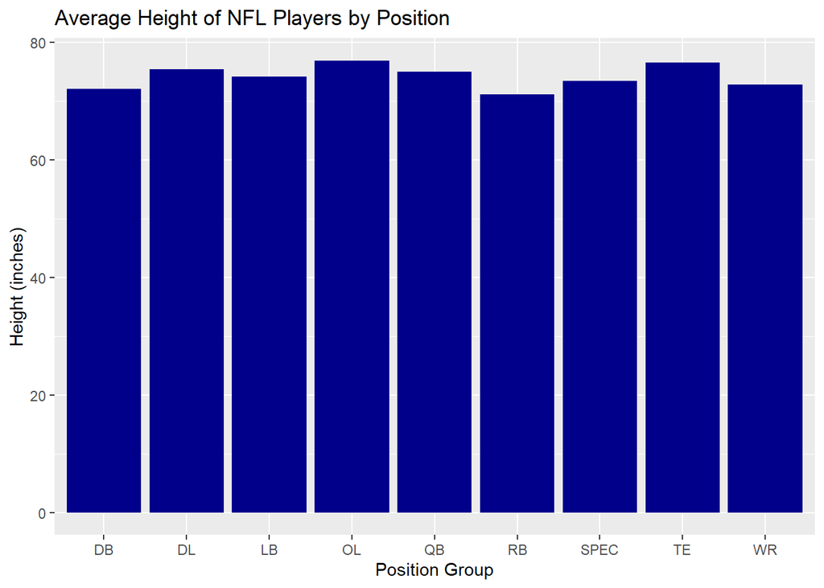

```r
ggplot(nfl_players_by_position, aes(x = position_group, y = average_height)) +
  geom_bar(stat = "identity", fill ="darkblue") +
  labs(title = "Average Height of NFL Players by Position", x = "Position Group", y = "Height (inches)")
```

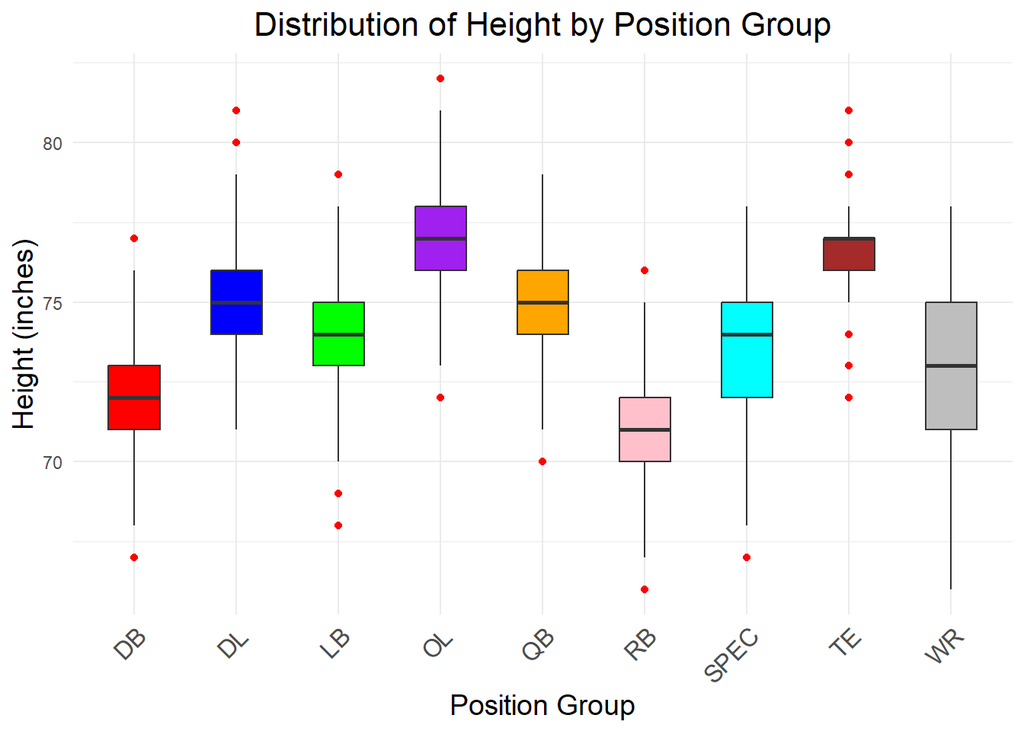

```r
my_colors <- c("red", "blue", "green", "purple", "orange", "pink", "cyan", "brown", "gray")

ggplot(nfl_data_clean, aes(x = position_group, y = height)) +
  geom_boxplot(fill=my_colors,show.legend = FALSE, outlier.color = "red", width = 0.5) +
  scale_fill_manual(values = c(my_colors, "gray")) +  # Add a color for "Other"
  labs(title = "Distribution of Height by Position Group",
       x = "Position Group",
       y = "Height (inches)") +
  theme_minimal() +
  theme(plot.title = element_text(size = 16, hjust = 0.5),  # Adjust title size and center it
        axis.title.x = element_text(size = 14),               # Adjust x-axis label size
        axis.title.y = element_text(size = 14),               # Adjust y-axis label size
        axis.text.x = element_text(size = 12, angle = 45, hjust = 1))  # Rotate x-axis labels
```

**From the above plots, we see that a player’s height tends to vary based on the position in which they play. To confirm this hypothesis, we conduct the ANOVA test for `height` vs `position_group`.**  
*Null hypothesis: Average height for each position group is equal*  
*Alternate hypothesis: Average height varies for each position group*

```r
anova_model_ht <- aov(height~position_group, nfl_data_clean)
xkabledply(anova_model_ht, title="ANOVA test Height vs Position Group")
```

ANOVA test Height vs Position Group

|  | Df | Sum Sq | Mean Sq | F value | Pr(>F) |
| --- | --- | --- | --- | --- | --- |
| position_group | 8 | 27132 | 3391.54 | 1105 | 0 |
| Residuals | 7089 | 21767 | 3.07 | NA | NA |

**The p-value from the ANOVA test is 0 which means that we reject the null hypothesis and accept the alternate. As expected, the distribution of player’s height varies based on the position group.**

## Weight

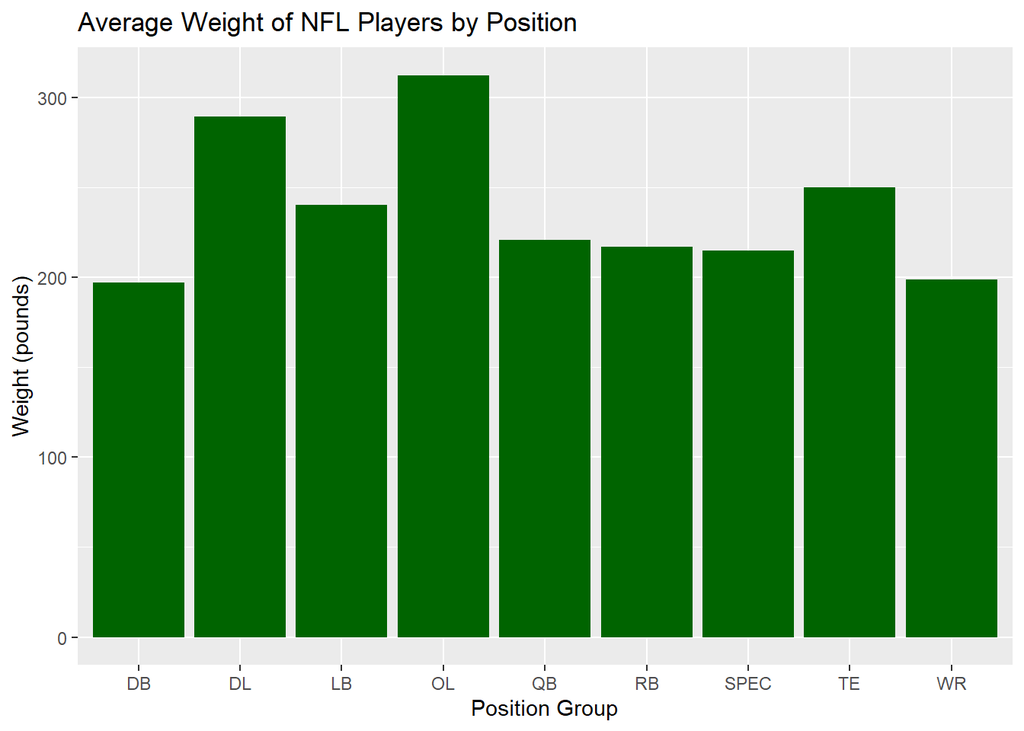

```r
ggplot(nfl_players_by_position, aes(x = position_group, y = average_weight)) +
  geom_bar(stat = "identity", fill = "darkgreen") +
  labs(title = "Average Weight of NFL Players by Position", x = "Position Group", y = "Weight (pounds)")
```

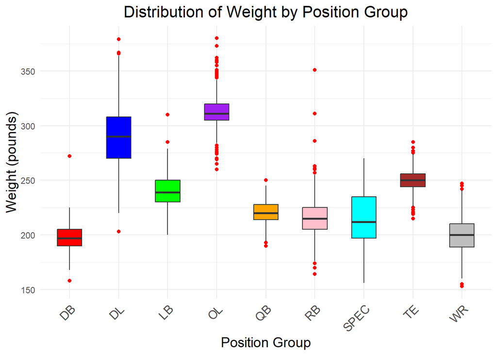

```r
ggplot(nfl_data_clean, aes(x = position_group, y = weight)) +
  geom_boxplot(fill=my_colors,show.legend = FALSE, outlier.color = "red", width = 0.5) +
  scale_fill_manual(values = c(my_colors, "gray")) +  # Add a color for "Other"
  labs(title = "Distribution of Weight by Position Group",
       x = "Position Group",
       y = "Weight (pounds)") +
  theme_minimal() +
  theme(plot.title = element_text(size = 16, hjust = 0.5),  # Adjust title size and center it
        axis.title.x = element_text(size = 14),               # Adjust x-axis label size
        axis.title.y = element_text(size = 14),               # Adjust y-axis label size
        axis.text.x = element_text(size = 12, angle = 45, hjust = 1))  # Rotate x-axis labels
```

**From the above plots, we see that a player’s weight tends to vary based on the position in which they play. To confirm this hypothesis, we conduct the ANOVA test for `weight` vs `position_group`**  
*Null hypothesis: Average weight for each position group is equal*  
*Alternate hypothesis: Average weight varies for each position group*

```r
anova_model_wt <- aov(weight~position_group, nfl_data_clean)
xkabledply(anova_model_wt, title="ANOVA test Weight vs Position Group")
```

ANOVA test Weight vs Position Group

|  | Df | Sum Sq | Mean Sq | F value | Pr(>F) |
| --- | --- | --- | --- | --- | --- |
| position_group | 8 | 13320702 | 1665088 | 6143 | 0 |
| Residuals | 7089 | 1921540 | 271 | NA | NA |

**The p-value from the ANOVA test is 0 which means that we reject the null hypothesis and accept the alternate. As expected, the distribution of player’s weight varies based on the position group.**

## Years of Experience

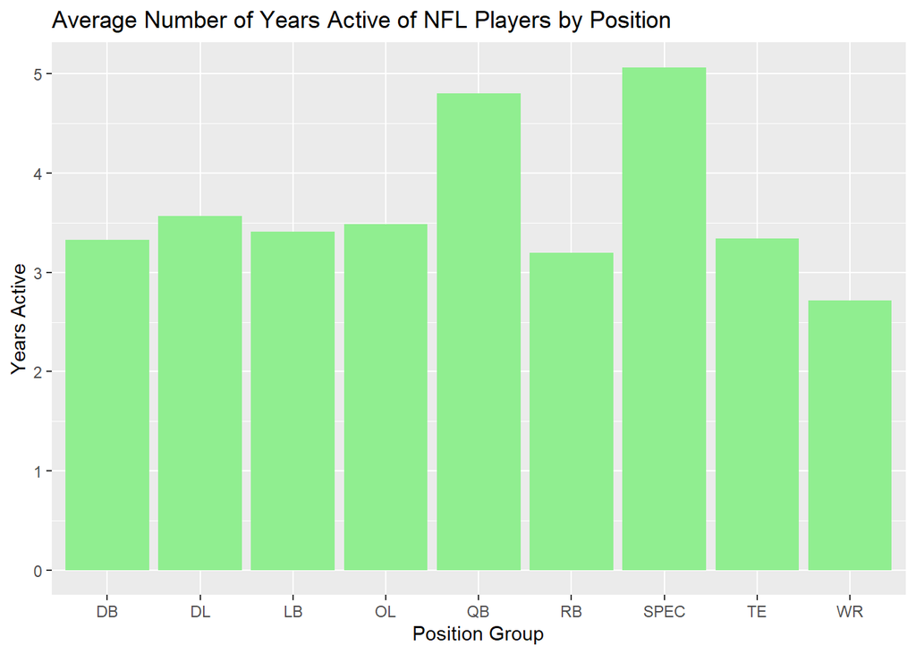

```r
ggplot(nfl_players_by_position, aes(x = position_group, y = average_years_active)) +
  geom_bar(stat = "identity", fill = "lightgreen") +
  labs(title = "Average Number of Years Active of NFL Players by Position", x = "Position Group", y = "Years Active")
```

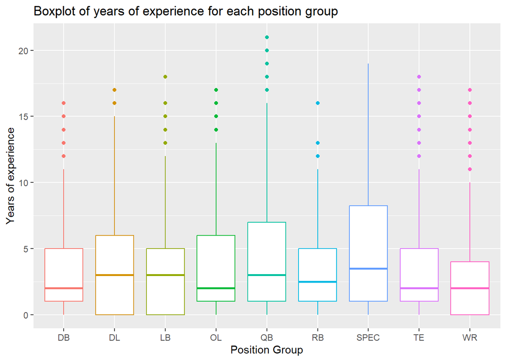

```r
ggplot(nfl_data_clean) +
  geom_boxplot(aes(x=position_group, y=years_of_experience, color=position_group), show.legend = F) +
  labs(title = "Boxplot of years of experience for each position group") +
  labs(x = "Position Group", y = "Years of experience")
```

**From the above plots, we see that a player’s YOE tends to vary based on the position in which they play. To confirm this hypothesis, we conduct the ANOVA test for `years_of_experience` vs `position_group`**  
*Null hypothesis: Average YOE for each position group is equal*  
*Alternate hypothesis: Average YOE varies for each position group*

```r
pos_yoe <- aov(years_of_experience ~ position_group, nfl_data_clean)
xkabledply(pos_yoe, title = "ANOVA test YOE vs Position Group")
```

ANOVA test YOE vs Position Group

|  | Df | Sum Sq | Mean Sq | F value | Pr(>F) |
| --- | --- | --- | --- | --- | --- |
| position_group | 8 | 1814 | 226.7 | 19.2 | 0 |
| Residuals | 7089 | 83864 | 11.8 | NA | NA |

**The p-value from the ANOVA test is 0 which means that we reject the null hypothesis and accept the alternate. As expected, the distribution of player’s YOE varies based on the position group.**